# Projekt1.0

Bartłomiej Kalata

25 kwietnia 2019

# Wprowadzenie i hipotezy:

W projekcie zostanie zbadana moc wybranych testów na normalność rozkładu. Dane pochodzić będą z rozkładu t-Studenta. Analiza wyników tych testów opierać się będzie o następujące parametry:

- Długości próby.
- Ilości stopni swobody w rozkładzie t.
- Poziomu istotności wybranego testu.

W projekcie zostaną użyte trzy testy badające normalność rozkładu:

- Jarque-Bera
- Shapiro-Wilka
- Kołmogorowa

## Test Jarque-Bera

W statystyce test ten sprawdza przy pomocy statystyki Jarque-Bera normalność rozkładu. Statystyka ta jest wspólna dla współczynnika skośności oraz dla kurtozy. Wyniki z niej są zawsze nieujemne. Jeżeli są one dalekie od zera, sygnalizuje to że dane nie mają normalnego rozkładu. Najczęsciej jest test ten używany jest dla dużej próbki. Hipotezą zerową w tym teście jest stwierdzenie, że próba pochodzi z rozkładu normalnego.

## Test Shapiro-Wilka

Test Shapiro-Wilka sprawdza w hipotezie zerowej czy próbka *x1,…..,xn* pochodzi z rozkłądu normalnego. Jest to preferowany test na normalność rozkładu ze względu na jego moc w porównaniu z innymi alternatywnymi testami. Test ten bazuje na spostrzeżeniu, iż analizując dopasowanie próbnego zbioru danych do rozkładu normalnego jest podobne do zadania liniowej regresji - linia diagonalna jest linią idealnego dopasowania, zaś wszystkie odchylenia od niej są podobne do residuów w zadaniu regresji. I właśnie analizując skalę tych odchyleń można określić jakość dopasowania. Dla dużej próbki nie będzie więc on bardzo wiarygodnym testem.

## Test Kołmogorowa-Smirnowa

Test Kołmogorowa-Smirnowa w statystyce jest nieparametrycznym testem, któy bazuje na maksymalnej różnicy pomiędzy rozkładem cechy *x* z hipotetycznym rozkładem *y*. W projekcie hipotetycznym rozkładem jest rozkład normalny. W teście Kołmogorowa hipotezą zerowa oznacza że, dwie porównywane próby mają taki sam rozkład.Dla dużych zbiorów danych ze względu na centralne twierdzenie graniczne, t-test powinien pozwalać na poprawne wyniki nawet w sytuacji dużego odstępstwa od rozkładu normalnego.

## Hipotezy:

- *Zmiana długości próby:*  
  H0: wraz ze zwiększaniem długości próby, test staje się mocniejszy. H1: wraz ze zwiększaniem długości próby, test staje się słabszy.
- *Zmiana ilości stopni swobody:*  
  H0: wraz ze zwiększaniem ilosci stopni swobody, test staje się słabszy.  
  H1: wraz ze zwiększaniem ilości stopni swobody, test staje się mocniejszy.
- *Zmiana poziomu istotności:*  
  H0: wraz ze zwiekszaniem poziomu istotności, test staje się mocniejszy. H1: wraz ze zwiekszaniem poziomu istotności, test staje się słabszy.

## Parametry o które zostanie oparta analiza zostaną wczytane jako wektory zmiennych.

# Wizualizacja:

### Wczytanie parametrów próbki pochodzącej z rozkładu t-Studenta:

```r
#Liczba Symulacji
N<- 500
#Poziom Istotnosci
alpha<- c(0.01, 0.05, 0.1, 0.2)
#Stopnie Swobody
stp_swb<-seq(1,15, by=1)
#Długość Próby
sample_length<-seq(15,30, by=1)
```

### Ramka danych:

Funkcja *expand grid* Tworzy ramkę danych ze wszystkich kombinacji dostarczonych wektorów lub czynników.

```r
frames<-expand.grid( Stopnie_Swobody=stp_swb,Poziom_Istotnosci=alpha,Dlugosc_Proby=sample_length)
```

### Podgląd danych:

```r
head(frames)
```

```
##   Stopnie_Swobody Poziom_Istotnosci Dlugosc_Proby
## 1               1              0.01            15
## 2               2              0.01            15
## 3               3              0.01            15
## 4               4              0.01            15
## 5               5              0.01            15
## 6               6              0.01            15
```

### Opis algorytmu:

Dla każdego wiersza w ramce danych *frames* obliczana jest moc testu. Aby w następnej kolejności stworzyć ramkę danych z wszystkimi wynikami wynik zapisywany jest do wektora, odpowiednio *Jarque_Bera*,*Kolmogorow*,*Shapiro-Wilk*.

### Test Jarque-Bera:

```r
set.seed(35)
Jarque_Bera<- sapply(1:nrow(frames),
                 function(i){
                   st_sw <- frames[i, 1]
                   alphy <- frames[i, 2]
                   sample_lengths <- frames[i, 3]
                   pvalue <- sapply(rep(st_sw, N), function(x){
                     my_sample <- rt(sample_lengths, st_sw)
                     jarque.bera.test(my_sample)$p.value
                   })
                   mean(pvalue < alpha)
                 })
```

### Test Kołmogorow-Smirnova:

```r
set.seed(35)
Kolmogorow <- sapply(1:nrow(frames),
                 function(i){
                   st_sw <- frames[i, 1]
                   alphy <- frames[i, 2]
                   sample_lengths <- frames[i, 3]
                   pvalue <- sapply(rep(st_sw, N), function(x){
                     my_sample <- rt(sample_lengths, st_sw)
                     ks.test(my_sample, pnorm)$p.value
                   })
                   mean(pvalue < alpha)
                 })
```

### Test Shapiro-Wilka:

```r
Shapiro_Wilk<-sapply(1:nrow(frames),function(i){
                   st_sw <- frames[i, 1]
                   alphy <- frames[i, 2]
                   sample_lengths <- frames[i, 3]
                   pvalue<-sapply(rep(st_sw,N),function(x){
                     my_sample<-rt(sample_lengths,st_sw)
                     shapiro.test(my_sample)$p.value
                   })
                   mean(pvalue<alpha)
})
```

### Stworzenie ramki danych z wszystkimi wynikami:

```r
frames_test<-bind_cols(frames,Moc_Testu_Jarque_Berq=Jarque_Bera,Moc_Testu_Kolomogorowa=Kolmogorow,Moc_Testu_Shapiro_Wilka = Shapiro_Wilk)
head(frames_test)
```

```
##   Stopnie_Swobody Poziom_Istotnosci Dlugosc_Proby Moc_Testu_Jarque_Berq
## 1               1              0.01            15                 0.672
## 2               2              0.01            15                 0.362
## 3               3              0.01            15                 0.236
## 4               4              0.01            15                 0.194
## 5               5              0.01            15                 0.156
## 6               6              0.01            15                 0.110
##   Moc_Testu_Kolomogorowa Moc_Testu_Shapiro_Wilka
## 1                  0.210                   0.772
## 2                  0.124                   0.456
## 3                  0.132                   0.314
## 4                  0.112                   0.246
## 5                  0.130                   0.176
## 6                  0.094                   0.150
```

### Wizualizacja każdego z testów

### Jarque-Bera:

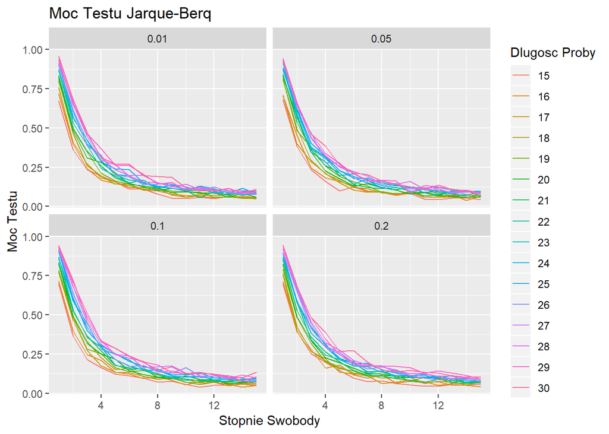

### Kołmogorowa-Smirnova:

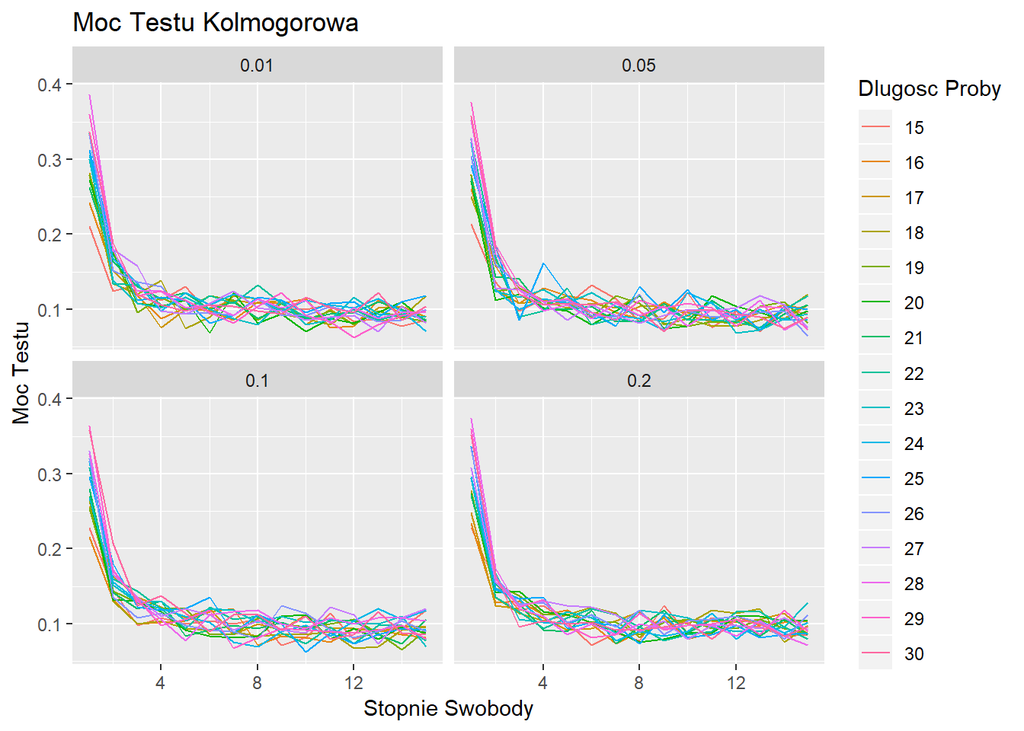

### Shapiro-Wilka:

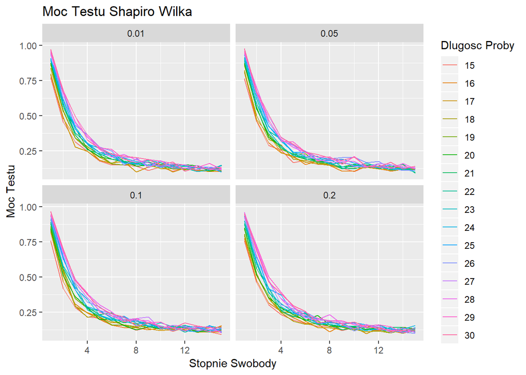

Shiny applications not supported in static R Markdown documents

# Interpretacja i wnioski

## Hipotezy:

### Zmiana długości próby.

Brak podstaw do odrzucenia hipotezy zerowej. Dla tej hipotezy oznacza to, że w przypadku zwiększenia długości próby *sample_length* wzrasta moc testu.

### Zmiana ilości stopni swobody.

Brak podstaw do odrzucenia hipotezy zerowej. Dla tej hipotezy oznacza to, że w przypadku zwiększenia stopni swobody *stp_swb* maleje moc testu.

## Interpretacja wykresów:

Na załączonych wykresach zauważyć możemy, że moc testu jest tym większa im większa jest długość próby, gdyż kolory mocy o wyższych wartościach *sample_length* znajdują się w wyższych partiach wykresów.

Jeżeli chodzi o stopnie swobody *stp_swb*, ich obecność ma znaczny wpływ na moc każdego z tych testów. Wyraźnie możemy zauważyć że wraz ze wzrostem liczby stopni swobody moc każdego z testów zmniejsza się.

## Wnioski z aplikacji SHINY:

- najmocniejszym z testów jest test Shapiro-Wilka, kolejnym Jarque-Bera, a najsłabszym Kołmogorowa-Smirnova.

## Możliwe Uproszczenia

- mała długość próbki.
- mała liczba symulacji.
- uproszczona wizualizacja mocy testów, może wpłynąć na miarodajność analizy ich mocy.